# Do Anti-Communist Fear-Mongering Campaigns shape Elections in Latin America? Evidence from Brazil, Chile, and Colombia using Google Trends Data

Flávia Batista & Juan Gelvez

December 12th, 2022

# 1. Introduction

The creation of common enemies in voters’ imaginary seems to be a trending strategy used by presidential candidates worldwide. George W. Bush’s “war on terror” in 2004 and Trump’s politicization of everything in 2016 and anti-China’s campaign in 2020 are some examples of fear-oriented campaigns deployed by presidential candidates to influence voters’ behavior in the U.S. In Latin America, candidates also use fear-mongering strategies, especially to spread fear around the “communist threat” supposedly represented by leftist candidates. Bolsonaro’s 2018 and 2022’s campaigns, for instance, brought “communism” and socialism” to the fore in Brazil. Intoning “Brazil cannot become a new Venezuela”, he connected the now president-elect Lula da Silva to Nicolas Maduro’s regime in Venezuela and fueled voters’ fear about an external communist threat during the last Brazilian General elections. In Colombia, the first-ever leftist president Gustavo Petro was also a target of an anti-communism fear mongering campaign perpetrated by his opponents during the last Colombian General Elections. Similarly, in Chile, the leftist and now president Gabriel Boric had to deal with several fear mongering strategies around his candidature and a “communist threat” deployed by his right-ring opponent Jose Antonio Kast during the last Chilean General Elections in December of 2021.

The heavenly use of anti-communism and anti-socialism fear-oriented campaigns in Latin America might negatively impact leftists’ vote share by associating their candidatures with a false communist threat. To further evaluate this question, this paper explores the use of anti-communist fear-mongering strategies during electoral campaigns in Latin America. More specifically, it examines the effect of targeting leftist candidates as “socialists” or “communists” or associating them with “Venezuela” on their subsequent vote share. We focus on the recent elections in Chile, Colombia, and Brazil and in the victory of the leftists Boric, Petro, and Lula, respectively. All three candidates won their presidential elections amid an intense fear-oriented campaign around the “communist threat” perpetrated by their opponents. This paper examines whether deploying fear-mongering campaigns around a communism threat harms leftist candidates’ state-level vote share (Borba 2021; Chagas, Modesto, and Magalhães 2019; Purdum, n.d.; Rhodes and Vayo 2019)

To conduct the analysis, we use data from Google Trends to measure people’s searches for the words “Venezuela”, “Communism”, and “Socialism” three months before the runoff elections in Brazil, Colombia, and Chile. We look for the intensity of the searches (i.e., number of hits) and the interest by region (i.e., the states with the most number of hits). We then match the Google Trends data with electoral data containing leftists’ vote share to assess the effect of anti-communist fear-mongering strategies on the electoral outcomes. We hypothesize that (i) people will search “Venezuela”, “Comunismo”, and “Socialismo” more as we get closer to election day; and (ii) that leftists candidates will have a lower vote share in states where the communist-related words had the most hits in Brazil, Colombia, and Chile.

# 2. Data

After getting information on the overall searches, we disagregated the data to get the search hits by each country’s states. We did this by creating a new object containing only the “interest by region” column from the main data set. This new object gives us the search hits for “communism”, “socialism”, and “Venezuela” for all countries by states. The “head()” command shows the 6 states with the most hits for each country.

Our last step was to obtain electoral data from the last elections for each country. We did this by collecting the vote share data from each country’s public available electoral organizations. For Brazil, we accessed the data at the Brazilian Superior Electoral Tribunal website (“https://resultados.tse.jus.br/oficial/app/index.html#/m/onboarding”) where they had the vote share for all candidates for the first and second rounds disagreggated by states. For Colombia, we collected the electoral data from the Registraduría Nacional del Estado Civil (“https://www.registraduria.gov.co/”) and for Chile at the Servicio Electoral de Chile website (“https://www.servel.cl/”). Finally, we merged data from all the countries and the search hits from Google Trends to create a data set with all the main variables. We used this to run the regression and assess our hypothesis.

All data used is available at https://github.com/juangelvezf/Google-trends-and-communism.

```r
# Getting data on the searches, 3 months before run-off
br <- gtrends(c("comunismo", "socialismo","venezuela"), geo = "BR", time = "2022-07-31 2022-10-31", low_search_volume = TRUE)  #Brazil
col <- gtrends(c("comunismo", "socialismo"), geo = "CO", time = "2022-03-20 2022-06-20", low_search_volume = TRUE)  #Colombia, no Venezuela
col1 <- gtrends(c("comunismo", "socialismo","venezuela"), geo = "CO", time = "2022-03-20 2022-06-20", low_search_volume = TRUE) #Colombia, with Venezuela
ch0 <- gtrends(c("comunismo", "socialismo"), geo = "CL", time = "2021-09-19 2021-12-19", low_search_volume = TRUE) #Chile, no Venezuela
ch <- gtrends(c("comunismo", "socialismo","venezuela"), geo = "CL", time = "2021-09-19 2021-12-19", low_search_volume = TRUE) #Chile, with Venezuela
```

# 3. Results

In this section, we present our data exploration and main results. We start by explaining how we explored the data using Google Trends and then we present our main findings from the OLS regression models.

## 3.1 Data exploration

Before running the models to test our hypotheses, we explored our data by looking at the relationship between proximity to election day and searching for communist-related words using Google Trends data. We then disaggregated the data by state to see where the search hits were stronger.

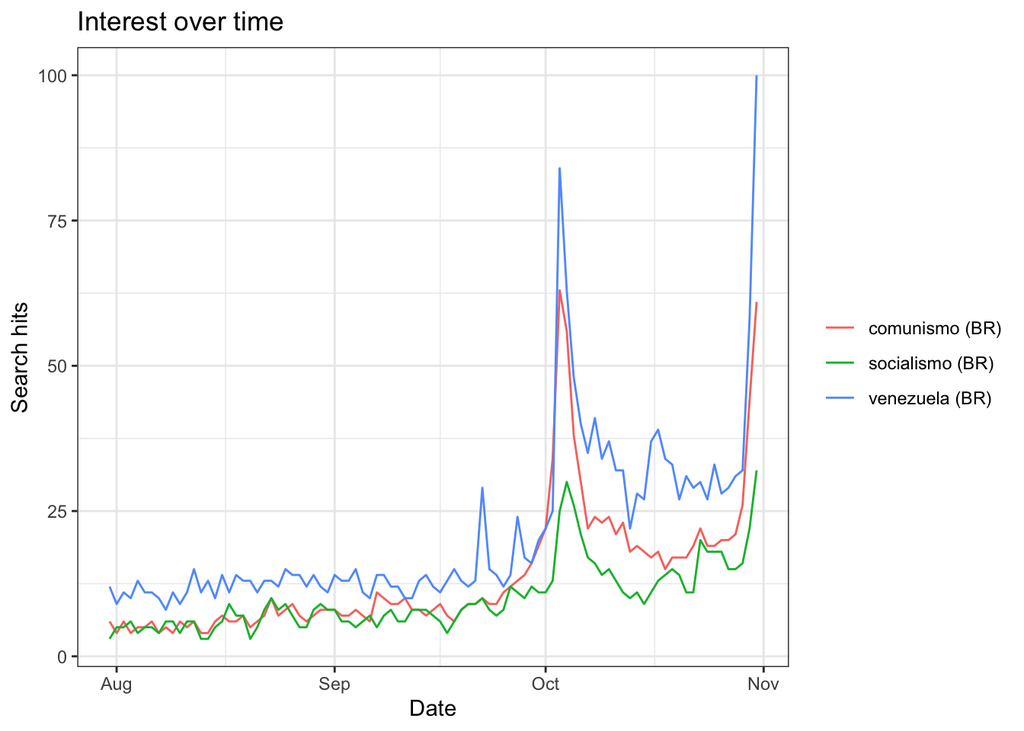

```r
# Google Trends plots for each country
plot(br) #Brazil
```

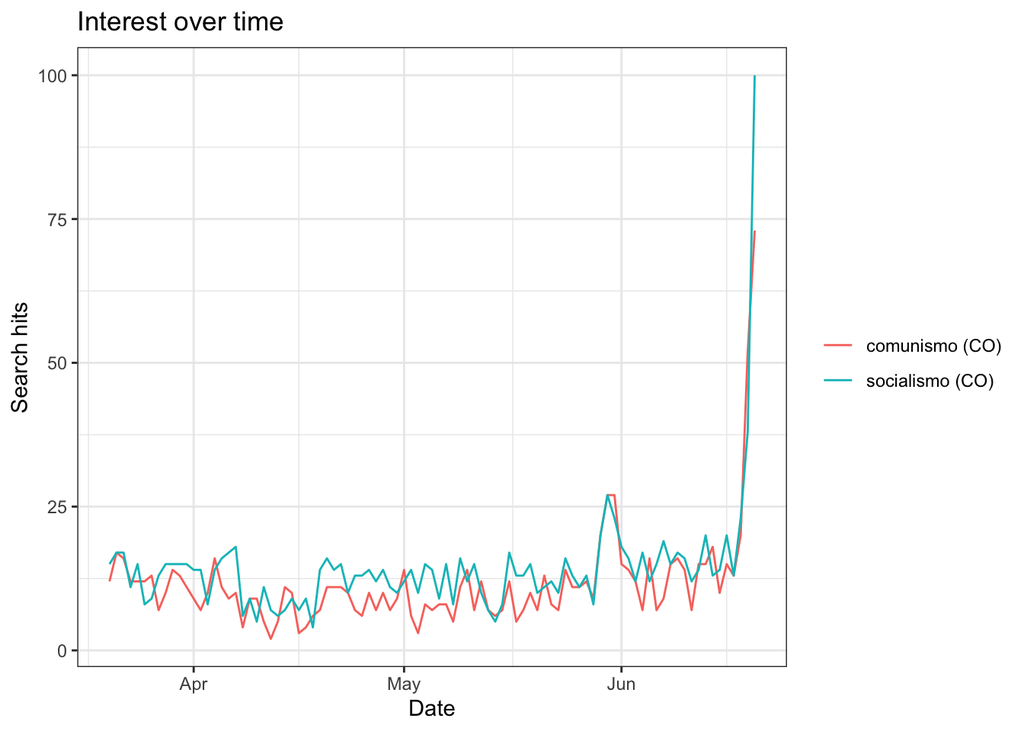

```r
plot(col) #Colombia
```

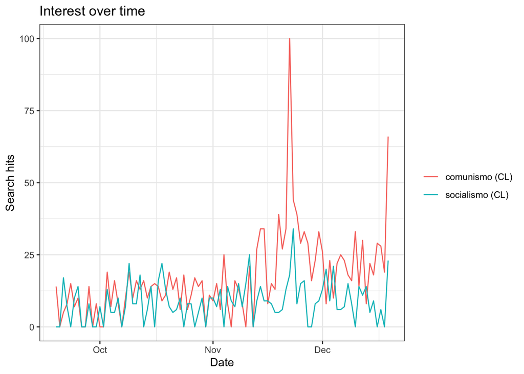

```r
plot(ch0) #Chile
```

```r
# Search Hits by State
head(br_byregion2) #Brazil
```

| location | geo | gprop | comunismo | socialismo | venezuela |
| --- | --- | --- | --- | --- | --- |
| State of Maranhão | BR | web | 100 | 94 | 9 |
| State of Tocantins | BR | web | 99 | 93 | 9 |
| State of Amapá | BR | web | 92 | 100 | 7 |
| State of Pará | BR | web | 88 | 85 | 9 |
| State of Rondônia | BR | web | 88 | 87 | 11 |
| State of Ceará | BR | web | 87 | 62 | 7 |

```r
head(col_byregion2) #Colombia
```

| location | geo | gprop | comunismo | socialismo | venezuela |
| --- | --- | --- | --- | --- | --- |
| Arauca | CO | web | 100 | 28 | 73 |
| Cesar | CO | web | 80 | 84 | 29 |
| Putumayo | CO | web | 78 | 65 | 27 |
| Boyaca | CO | web | 75 | 66 | 23 |
| Cordoba | CO | web | 75 | 100 | 18 |
| Caldas | CO | web | 71 | 83 | 18 |

```r
head(ch_byregion2)#Chile
```

| location | geo | gprop | comunismo | socialismo | venezuela |
| --- | --- | --- | --- | --- | --- |
| XI Región | CL | web | 100 | NA | 68 |
| Los Ríos Region | CL | web | 81 | 39 | 47 |
| Magallanes y la Antártica Chilena Region | CL | web | 75 | 100 | 59 |
| Maule Region | CL | web | 65 | 18 | 72 |
| Bío Bío Region | CL | web | 61 | 55 | 54 |
| Santiago Metropolitan Region | CL | web | 59 | 57 | 100 |

## 3.2 Analysis

We raise two main hypotheses in this paper. First, we hypothesize that the search hits for “Venezuela”, “Comunismo”, and “Socialismo” will increase as we get closer to elections’ day in Brazil, Chile, and Colombia. Second, we expect that left-wing candidates will have a lower vote-share where the search hits for these words are higher. To test our theory, we run two OLS models.

The first model takes the search for the three words as the dependent variable and the proximity to the election day as the main independent variable. This latter ranges from -90 to 0 days before elections. We also included country-fixed effects, with Brazil being the excluded category. The model output is shown below. Our results suggest that proximity to election day is positively associated with Google searches for communism-related words. One unit increase in the days before the election variable leads to an increase in the search for “Venezuela”, “Comunismo” and “Socialismo by 0.056 points, 0.164 points, 0.071 points, respectively, on average, holding all else constant.

```r
# Hypothesis 1
lm_venezuela_time <- lm(venezuela ~ before_election+geo, data=by_time)
lm_comunismo_time <- lm(comunismo ~ before_election+geo, data=by_time)
lm_socialismo_time <- lm(socialismo ~ before_election+geo, data=by_time)

#Regression output
reg_h1 <- list(lm(venezuela ~ before_election+geo, data=by_time),
                       lm(comunismo ~ before_election+geo, data=by_time),
                       lm(socialismo ~ before_election+geo, data=by_time))
reg_h1<- outreg(reg_h1)
reg_h1
```

|  | .variable | .stat | Model 1 | Model 2 | Model 3 |
| --- | --- | --- | --- | --- | --- |
| 1 | (Intercept) | Estimate | 23.857*** | 20.721*** | 12.913*** |
| 2 |  | Std Err | [2.105] | [1.386] | [0.761] |
| 5 | before_election | Estimate | 0.056* | 0.164*** | 0.071*** |
| 6 |  | Std Err | [0.033] | [0.022] | [0.012] |
| 9 | geoCL | Estimate | -13.565*** | 8.915*** | -1.060 |
| 10 |  | Std Err | [2.190] | [1.442] | [0.792] |
| 13 | geoCO | Estimate | -10.067*** | -12.412*** | -8.743*** |
| 14 |  | Std Err | [2.075] | [1.366] | [0.750] |
| 17 |  | N | 258 | 258 | 258 |
| 18 |  | R2 | 0.150 | 0.539 | 0.439 |

[output cut: 2 more lines]

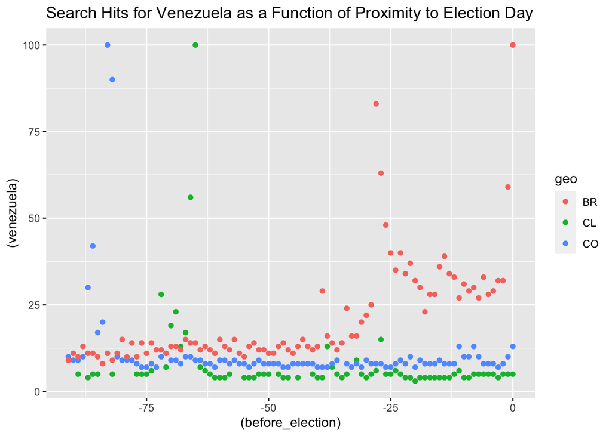

```r
#Vezuela in the three countries
ggplot(by_time) +
  aes(x = (before_election), y = (venezuela), colour = geo) +
  geom_point() +
  scale_color_hue() + ggtitle("Search Hits for Venezuela as a Function of Proximity to Election Day")
```

The regression results and the correlation plot for the second hypothesis are shown below. The dependent variable is the vote share at the state-level in the run-off for the three left-wing candidates in Brazil, Chile, and Colombia. The independent variable are the Google searches for the three words (Venezuela, Socialismo, and Comunismo). We focus only on the run-off because (i) third parties usually have a significant effect on vote shares in the first round and (ii) abstention is lower in the second round. We also included country-fixed effects, with Brazil being the excluded category. Our results suggest that searches for Venezuela are negatively and significantly correlated with left-wing party vote share in the second round, on average, holding all else constant. One unit increase in the search for “Venezuela” decreases vote share for left-wing candidates by 0.314 points. Searches for “Comunismo” and “Socialismo” do not have a significant relationship with the left-wing candidates’ vote share. The correlation plot shows the negative relationship between Venezuela search hits and leftists’ vote share in the second round, as predicted from our model.

```r
# Hypothesis 2

#Model
reg_by_region <- list (lm(left_second ~ venezuela + geo, data=by_region),
                       lm(left_second ~ comunismo + geo, data=by_region),
                       lm(left_second ~ socialismo + geo, data=by_region)
                       )
reg_by_region<- outreg(reg_by_region)
reg_by_region
```

|  | .variable | .stat | Model 1 | Model 2 | Model 3 |
| --- | --- | --- | --- | --- | --- |
| 1 | (Intercept) | Estimate | 53.901*** | 45.301*** | 50.111*** |
| 2 |  | Std Err | [3.189] | [10.798] | [8.069] |
| 5 | venezuela | Estimate | -0.314** |  |  |
| 6 |  | Std Err | [0.119] |  |  |
| 9 | geoCL | Estimate | 23.084*** | 5.414 | 5.046 |
| 10 |  | Std Err | [8.677] | [5.635] | [6.134] |
| 13 | geoCO | Estimate | 5.987 | 1.415 | 1.153 |
| 14 |  | Std Err | [4.429] | [4.280] | [4.308] |
| 17 | comunismo | Estimate |  | 0.064 |  |
| 18 |  | Std Err |  | [0.138] |  |

[output cut: 6 more lines]

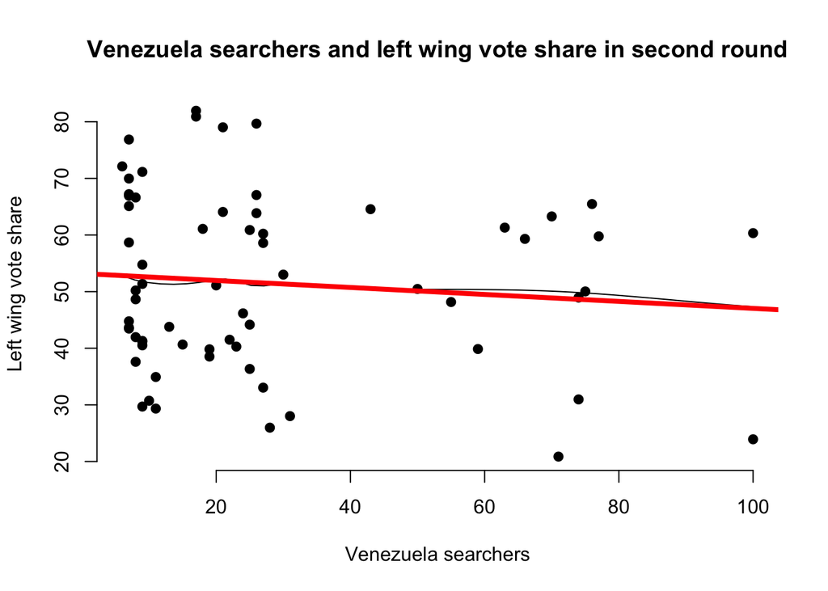

```r
#Correlation Plot
scatter.smooth(by_region$venezuela, by_region$left_second,
               main="Venezuela searchers and left wing vote share in second round",
               xlab= "Venezuela searchers",
               ylab="Left wing vote share",
               pch = 19, frame = FALSE)
abline(lm(left_second ~ venezuela, data = by_region), col='red',lwd=4)
```

# 4. Discussion

We need to address three issues for our results to be sustained. One is related to how information spreads and when people decide to search for anti-communist words. The data show that people are more likely to use this search string late in the election campaign when people are less informed and information is confusing. Our results stand on solid ground here as people continue to search for these words as the political campaign evolves. Yet we should further research the ‘lifespan’ of some terms related to their ability to survey populations, considering that their use might drop as information gets more transparent and people become more informed. Second, our choice to use data at the state level may raise questions regarding whether national or city-level data matter. People inform themselves in the federal and local news and use that information, so it would be interesting to analyze city-level data as well. Lastly, people could search our three main words because they have a left-wing political affiliation. While plausible, we do not believe this could be driving our results. Communist and socialist parties got less than 10% of the vote share in the congress elections in each country, so it is not a majority. In any case, we would have to control for that to make sure our model does not suffer from endogeneity.

# 5. References

Borba, Rodrigo. 2021. “Disgusting Politics: Circuits of Affects and the Making of Bolsonaro.” *Social Semiotics* 31 (5): 677–94. https://doi.org/10.1080/10350330.2020.1810554.

Chagas, Viktor, Michelle Modesto, and Dandara Magalhães. 2019. “O Brasil Vai Virar Venezuela: Medo, Memes e Enquadramentos Emocionais No WhatsApp Pró-Bolsonaro.” *Esferas*, no. 14 (August): 1. https://doi.org/10.31501/esf.v0i14.10374.

Purdum, Todd S. n.d. “The 2016 Race Isn’t about Issues. It’s about Character.” *POLITICO Magazine*. https://www.politico.com/magazine/story/2016/08/does-anyone-care-about-issues-anymore-or-only-whether-trump-is-crazy-214150.

Rhodes, Jesse H., and Amber B. Vayo. 2019. “The Historical Presidency: Fear and Loathing in Presidential Candidate Rhetoric, 1952–2016.” *Presidential Studies Quarterly* 49 (4): 909–31. https://doi.org/10.1111/psq.12512.